# Script 1 - Checagem da qualidade dos dados

André Vizzoni

2025-05-07

# Preâmbulo

Pacote necessário.

```r
library(tidyverse)
```

# Leitura dos dados

Primeiro, vamos ler os dados.

```r
dados <- read.csv(
  "player_stats.csv",
  colClasses = c(
    "GameID" = "character",
    "RedTeamID" = "character",
    "BlueTeamID" = "character"
  )
)
glimpse(dados)
```

```
## Rows: 26,110
## Columns: 19
## $ GameID             <chr> "114195663864132013", "114195663864132013", "114195…
## $ RedTeamID          <chr> "99566404848691211", "99566404848691211", "99566404…
## $ BlueTeamID         <chr> "99566404850008779", "99566404850008779", "99566404…
## $ League             <chr> "LPL", "LPL", "LPL", "LPL", "LPL", "LPL", "LPL", "L…
## $ RedTeamName        <chr> "Suzhou LNG Ninebot Esports", "Suzhou LNG Ninebot E…
## $ BlueTeamName       <chr> "Invictus Gaming", "Invictus Gaming", "Invictus Gam…
## $ Role               <chr> "top", "jungle", "mid", "bottom", "support", "top",…
## $ ChampionID         <chr> "Rumble", "Sejuani", "Corki", "Kaisa", "Rell", "Gwe…
## $ PlayerName         <chr> "LNGZika", "LNGWeiwei", "LNGhaichao", "LNGPhotic", …
## $ PatchVersion       <chr> "15.6.665.8352", "15.6.665.8352", "15.6.665.8352", …
## $ Kills              <int> 5, 2, 4, 4, 0, 1, 3, 0, 1, 0, 0, 6, 1, 2, 1, 1, 6, …
## $ Deaths             <int> 1, 2, 1, 0, 1, 5, 2, 2, 1, 5, 3, 2, 4, 1, 3, 1, 1, …
## $ Assists            <int> 6, 12, 2, 2, 10, 2, 2, 2, 1, 1, 2, 1, 3, 4, 5, 3, 4…
## $ OpposingChampionID <chr> "Gwen", "Naafiri", "Ryze", "Ezreal", "Braum", "Rumb…
## $ OpposingPlayerName <chr> "IGTheShy", "IGJiejie", "IGRookie", "IGGALA", "IGMe…
## $ CSAt15Min          <int> 112, 80, 133, 120, 20, 83, 114, 133, 133, 18, 104, …
## $ GoldAt15Min        <int> 5274, 5165, 5669, 4943, 3344, 4944, 5333, 4856, 488…
## $ CSAtEnd            <int> 185, 130, 237, 230, 27, 174, 196, 234, 239, 25, 297…
## $ GoldAtEnd          <int> 9391, 8279, 10075, 10504, 5517, 9103, 9264, 8607, 9…
```

E agora vamos fazer algumas checagens em cada coluna.

## Coluna GameID

```r
sort(table(dados$GameID), decreasing = TRUE)
```

```
##
## 113470687277255856 113470687277255859 113470687277255863 113470687277255864
##                 10                 10                 10                 10
## 113470687277255868 113470687277255871 113470687277255872 113470687277255873
##                 10                 10                 10                 10
## 113470687277255875 113470687277255876 113470687277255877 113470687277255879
##                 10                 10                 10                 10
## 113470687277255880 113470687277255881 113470687277255884 113470687277255885
##                 10                 10                 10                 10
## 113470687277255887 113470740396151228 113470740396413373 113470740396413374
##                 10                 10                 10                 10
## 113470740396478912 113470740396478913 113470740396478916 113470740396478917
##                 10                 10                 10                 10
## 113470740396478920 113470740396478921 113470740396478924 113470740396478926
##                 10                 10                 10                 10
```

[output cut: 1292 more lines]

Essa coluna parece estar como deveria, com 10 indivíduos por id.

## Coluna RedTeamID

```r
sort(
  table(dados$RedTeamID),
  decreasing = T
)
```

```
##
## 100205573496804586 105550059790656435 105550051809743868  99566404853854212
##                300                260                250                250
##  99566404854685458 100725845018863243 105515219038427019  98767991853197861
##                250                240                240                220
##  99566404852189289 105550033967461806 107563714667537640 110412519932278090
##                220                210                210                210
## 111692118851466302  98767991887166787 100205573495116443 102747101565183056
##                210                210                200                200
## 105550049871017396  99566404856367466 105503948999800557 105550042327365041
##                200                200                190                190
## 107251245690956393 107700199633958891  98767991866488695  99566404848691211
##                190                190                190                190
##  99566404853058754  99566404855553726 101388912911039804 107603608999191393
##                190                190                180                180
```

[output cut: 122 more lines]

Essa também.

## Coluna RedTeamName

```r
sort(
  table(dados$RedTeamName),
  decreasing = T
)
```

```
##
##                    TOPESPORTS                  Karmine Corp
##                           290                           260
##            T1 Esports Academy             THUNDERTALKGAMING
##                           240                           240
##                 Zero Tenacity   Berlin International Gaming
##                           240                           230
##           Hanwha Life Esports    BILIBILI GAMING DREAMSMART
##                           230                           210
##                     DN FREECS                        GIANTX
##                           210                           210
##                Ici Japon Corp                  Misa Esports
##                           210                           210
##                NS Challengers            West Point Esports
##                           210                           210
##                     Dplus KIA               Invictus Gaming
##                           200                           200
##                kt Challengers                   Los Ratones
##                           200                           200
##          Papara SuperMassive           WeiboGaming Faw Audi
##                           200                           200
##                DK Challengers                           DRX
##                           190                           190
##                        Fnatic               FunPlus Phoenix
##                           190                           190
##                Geekay Esports               HLE Challengers
##                           190                           190
##           OKSavingsBank BRION      Austrian Force willhaben
##                           190                           180
##            CTBC Flying Oyster                       Galions
##                           180                           180
##                    kt Rolster                   Ultra Prime
##                           180                           180
##               Anyone's Legend                 Barça Esports
##                           170                           170
##               BNK FEARX Youth          Gen.G Global Academy
##                           170                           170
##            NONGSHIM RED FORCE                 Forsaken Team
##                           170                           160
##             Karmine Corp Blue                  Movistar KOI
```

[output cut: 216 more lines]

```
##                            10                            10
##                     Crusaders                  DeltanGaming
##                            10                            10
##             Fantastic Esports      For the Win Esports Club
##                            10                            10
##                GrowUp Esports                  Inside Games
##                            10                            10
##           Maze Gaming Esports                     Night Cap
##                            10                            10
##               Partizan Sangal            Underworld Esports
##                            10                            10
##                    V3 Esports                      VeLocitY
##                            10                            10
##                    We Can Win
##                            10
```

## Colunas RedTeamID vs. RedTeamName

```r
sort(
  table(
    paste(
      dados$RedTeamID,
      dados$RedTeamName,
      sep = " - "
    )
  )
  ,
  decreasing = T
)
```

```
##
##            107760667929003738 - West Point Esports
##                                                100
##                105515219038427019 - Ici Japon Corp
##                                                 70
##             113843163628949793 - Saigon Team Flash
##                                                 70
##           99566404853854212 - WeiboGaming Faw Audi
##                                                 70
##                  105515345386578249 - Gentle Mates
##                                                 60
##            105550049871017396 - T1 Esports Academy
##                                                 60
##                105550059790656435 - kt Challengers
##                                                 60
##            107251245690956393 - CTBC Flying Oyster
##                                                 60
##                109696073114910519 - Geekay Esports
##                                                 60
##                 110412519932278090 - Forsaken Team
##                                                 60
##                   99566406064558732 - Eternal Fire
##                                                 60
##           100205573495116443 - Hanwha Life Esports
##                                                 50
##           100725845018863243 - Hanwha Life Esports
##                                                 50
##                        102787200124959636 - BeFive
##                                                 50
##            104367068120825486 - CTBC Flying Oyster
##                                                 50
##            105550033967461806 - T1 Esports Academy
##                                                 50
##            105550042327365041 - T1 Esports Academy
##                                                 50
##          105550051809743868 - Gen.G Global Academy
##                                                 50
## 107251245690956393 - Fukuoka SoftBank HAWKS gaming
##                                                 50
##                         107251245690956393 - Talon
```

[output cut: 3006 more lines]

```
##                                                 10
##                99566408217955692 - Vivo Keyd Stars
##                                                 10
##                       99566408221961358 - LEVIATÁN
##                                                 10
##                           99566408221961358 - LOUD
##                                                 10
##                99566408221961358 - Vivo Keyd Stars
##                                                 10
##                    99566408562477641 - ODD Esports
##                                                 10
##                    99566408562477641 - Peek Gaming
##                                                 10
##                   99566408562477641 - Zeu5 Esports
##                                                 10
```

As diferenças entre as duas colunas de time vermelho são porque cada time recebe um id novo quando muda a competição. Presumo que o mesmo valha para os times azuis.

## Coluna League

```r
sort(
  table(dados$League),
  decreasing = T
)
```

```
##
##                     LPL         LCK Challengers                     LCK
##                    2660                    1790                    1750
##                     LEC            Prime League            Rift Legends
##                    1440                    1310                    1130
##                     TCL        Hitpoint Masters      La Ligue Française
##                    1100                    1020                    1020
##                     PCS          Arabian League               SuperLiga
##                    1010                     960                     960
##                     LCP                     LJL     Circuito Desafiante
##                     910                     830                     790
##                     NLC Hellenic Legends League         Road of Legends
##                     770                     720                     700
##                    NACL               LTA South               LTA North
##                     670                     630                     610
##            EMEA Masters  LoL Italian Tournament         Liga Portuguesa
##                     540                     480                     430
##                     LRN                     VCS   Esports Balkan League
##                     430                     390                     330
##                     LRS             First Stand    LTA Cross-Conference
##                     270                     260                     130
##   North Regional League   South Regional League
##                      40                      30
```

## Coluna Role

```r
sort(
  table(dados$Role),
  decreasing = T
)
```

```
##
##  bottom  jungle     mid support     top
##    5222    5222    5222    5222    5222
```

## Coluna ChampionID

```r
sort(
  table(dados$ChampionID),
  decreasing = T
)
```

```
##
##         Rell       Ezreal        Varus      Ambessa        Corki      XinZhao
##          877          826          809          749          728          705
##        Leona     Nautilus           Vi      Alistar         Azir        Rakan
##          653          617          608          604          595          595
##      Sejuani        Jayce       Rumble      Taliyah  MissFortune        Kaisa
##          595          585          584          548          526          515
##       KSante         Ahri       Maokai         Yone       Viktor       Aurora
##          513          478          451          451          438          417
##        Braum     Pantheon         Jhin        Poppy      Skarner   MonkeyKing
##          388          376          368          361          359          349
##         Ashe     Renekton         Sion         Gnar          Jax      Orianna
##          344          308          305          298          294          291
##      Naafiri         Gwen        Galio        Viego        Sylas      Kalista
##          279          278          274          255          235          233
##         Ryze     Tristana        Xayah       Renata       Lillia         Zyra
##          232          230          224          214          210          210
##       Aatrox        Neeko     Nocturne         Hwei        Akali         Ornn
##          201          196          196          195          190          169
##         Jinx         Zeri        Karma       Gragas      Camille        Sivir
##          161          136          135          132          130          122
##      Nidalee         Lulu       Syndra        Ivern       LeeSin      Caitlyn
##          121          116          114          112          103          100
##     JarvanIV        Elise         Bard        Ziggs          Mel       Yorick
##           95           93           88           76           73           63
##      Chogath   Blitzcrank       Lucian      Smolder       Draven         Pyke
##           60           52           52           49           47           47
##         Olaf         Shen      Leblanc      Kindred    Seraphine     Volibear
##           42           40           39           38           38           37
##      DrMundo   Cassiopeia       Darius        Fiora         Udyr        Yasuo
##           35           34           33           33           33           33
##       Thresh     Vladimir        Garen        Amumu       Kennen       Irelia
##           32           32           30           28           27           26
##        Swain        Annie     Aphelios     Malphite         Nami  AurelionSol
##           26           25           25           25           24           23
##        Brand    Gangplank        Senna        Milio         Sett        Diana
##           23           23           21           20           20           18
##        Taric       Xerath          Zac      Karthus          Zed  Mordekaiser
##           18           18           18           17           17           16
##       Anivia FiddleSticks        Janna       KogMaw      Warwick        Yuumi
##           15           15           14           13           13           13
##       Zilean      Belveth    Lissandra          Lux    TahmKench      Trundle
##           13           12           12           12           12           12
##       Twitch          Vex          Zoe   Tryndamere        Vayne       Velkoz
##           11           11           10            9            9            9
##         Kayn         Nunu        Nilah       Soraka        Urgot       Veigar
##            8            8            7            7            7            7
##      Hecarim     Kassadin      Morgana        Kayle       Khazix       RekSai
##            6            6            5            4            4            4
##  TwistedFate         Kled         Ekko       Graves     Katarina        Nasus
##            4            3            2            2            2            2
##        Quinn       Rengar        Riven      Shyvana       Akshan     MasterYi
##            2            2            2            2            1            1
##       Samira        Shaco       Singed         Sona
##            1            1            1            1
```

## Coluna PlayerName

```r
sort(
  table(dados$PlayerName),
  decreasing = T
)
```

```
##
##      HLE Delight       HLE Peanut        HLE Viper         HLE Zeka
##               53               53               53               53
##         HLE Zeus        T1 Cloud         T1 Haetae          T1 Poby
##               53               50               50               50
##      T1 Vincenzo       KC Caliste         KC Canna      KC Targamas
##               50               47               47               47
##         KC Vladi          KC Yike           BLGBin           BLGElk
##               47               47               46               46
##        BLGKnight            BLGON        DK Aiming         DK BeryL
##               46               46               44               44
##         DK Lucid     DK ShowMaker         DK Siwoo           TES369
##               44               44               44               44
##         TESCreme         TESCrisp    TESJackeyLove        TESKanavi
##               44               44               44               44
##       BFX Career      BFX Daystar        BFX Envyy       BFX Soboro
##               42               42               42               42
##        NS Fisher            TT1xn        TTFeather           TTHOYA
##               42               42               42               42
##          TTSeTab          KCB 3XA      KCB Maynter        KCB SlowQ
##               42               40               40               40
##      KT YoungJae         KT Zinie       DRX Pleata           IGGALA
##               40               40               39               39
##         IGJiejie          IGMeiko         IGRookie         IGTheShy
##               39               39               39               39
##    IJC Hans SamD      IJC Howling        IJC Prime      IJC Sertuss
##               39               39               39               39
##     IJC Theocacs        KT Paduck       WBGBreathe         WBGLight
##               39               39               39               39
##          WBGTian        WBGXiaohu           BLGWei     FNC Humanoid
##               39               39               38               38
##        FNC Mikyx    FNC Oscarinin       FNC Razork        FNC Upset
##               38               38               38               38
##       KT Casting        ALFlandre           ALHope           ALKael
##               38               37               37               37
##         ALShanks         ALTarzan        CFO Doggo        CFO HongQ
##               37               37               37               37
##       CFO JunJia      CFO Kaiwing          FPXCare          FPXJwei
##               37               37               37               37
##         FPXsheer           KT Way        NS GIDEON         NS Jiwoo
```

[output cut: 872 more lines]

```
##                1                1                1                1
##         NF Oshii       NGX Bey0nd     NORD Ronaldo          ODD Tyr
##                1                1                1                1
##       OSC Kwebz1        OSC RaFaL        TML Vodin        TPX Chova
##                1                1                1                1
##  TPX Hildebrandt      TPX Jimsnop      VEL BEEHIV3         VEL fuki
##                1                1                1                1
##       VEL Lambda       VEL Skinny         VEL tetu         VER MAXI
##                1                1                1                1
##        VK Jmicta   VK motimotti11       VK Sag1rii          VK udon
##                1                1                1                1
##     VK velbellys      WAP Frixter        WT yukin0        ZENA Druk
##                1                1                1                1
##         ZZG sall
##                1
```

## Coluna PatchVersion

```r
sort(
  table(dados$PatchVersion),
  decreasing = T
)
```

```
##
##  15.8.675.448 15.7.671.9073  15.3.655.330 15.4.658.6996 15.1.649.4112
##          4710          3540          2760          1960          1840
## 15.6.667.3303 15.2.653.8382 15.5.662.5311  15.9.678.398 15.2.652.6393
##          1800          1710          1300          1290          1000
## 15.7.670.1561 15.3.659.3416 15.8.674.6483 15.7.669.5499 15.6.665.8352
##           930           750           620           590           460
## 15.4.657.5386  15.9.677.562 15.2.650.9216 15.1.645.7528 15.1.648.3927
##           230           220           210            70            40
## 15.2.652.1536 15.8.673.8718 15.7.668.6919
##            40            30            10
```

## Coluna Kills

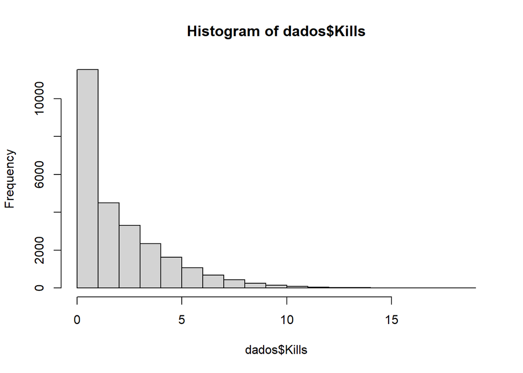

```r
hist(dados$Kills)
```

## Coluna Deaths

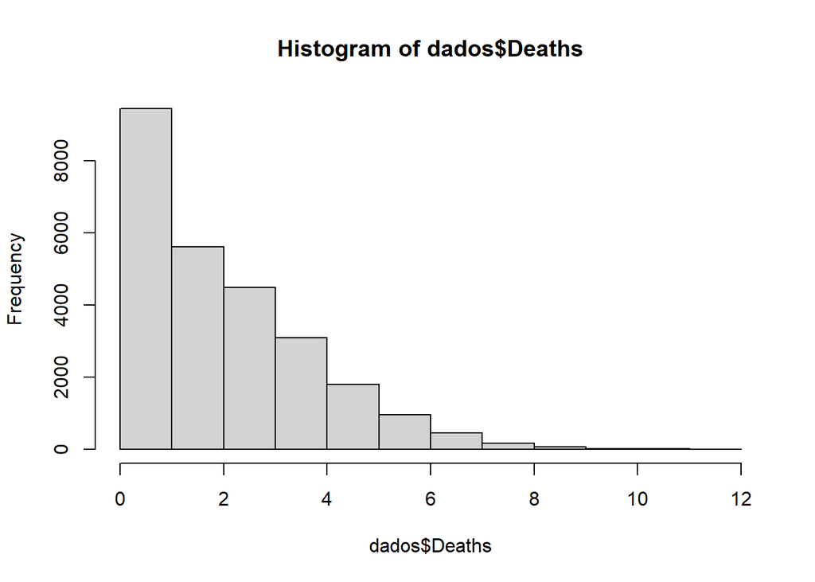

```r
hist(dados$Deaths)
```

## Colunas Kills vs. Deaths

```r
sum(dados$Deaths) - sum(dados$Kills)
```

```
## [1] 121
```

Esse é o número de abates que não tiveram responsabilidade de um jogador.

## Coluna Assists

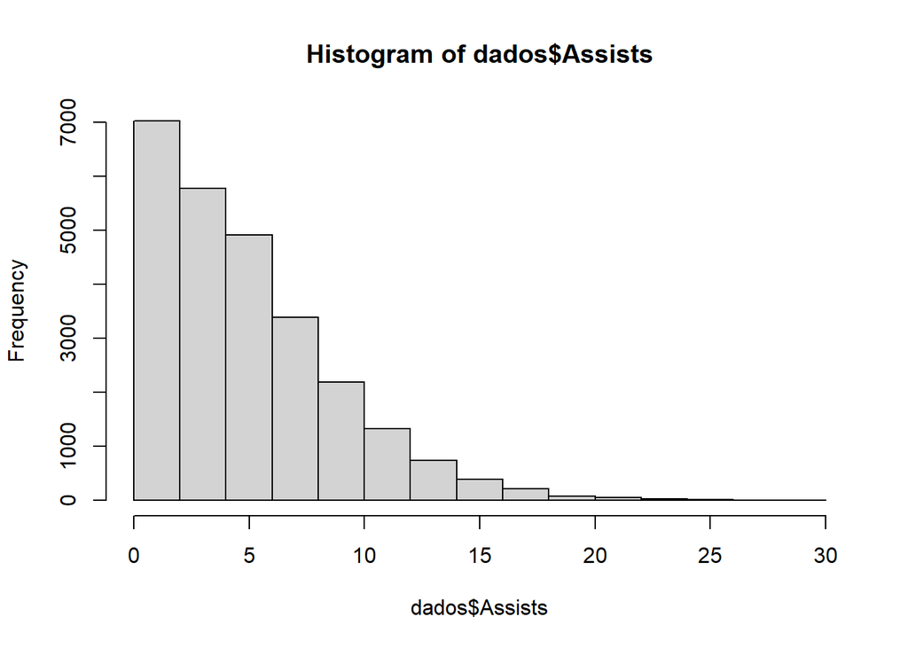

```r
hist(dados$Assists)
```

```r
sum(dados$Assists) / sum(dados$Deaths)
```

```
## [1] 2.214437
```

## Coluna OpposingChampionID

```r
sort(
  table(dados$OpposingChampionID),
  decreasing = T
)
```

```
##
##         Rell       Ezreal        Varus      Ambessa        Corki      XinZhao
##          877          826          809          749          728          705
##        Leona     Nautilus           Vi      Alistar         Azir        Rakan
##          653          617          608          604          595          595
##      Sejuani        Jayce       Rumble      Taliyah  MissFortune        Kaisa
##          595          585          584          548          526          515
##       KSante         Ahri       Maokai         Yone       Viktor       Aurora
##          513          478          451          451          438          417
##        Braum     Pantheon         Jhin        Poppy      Skarner   MonkeyKing
##          388          376          368          361          359          349
##         Ashe     Renekton         Sion         Gnar          Jax      Orianna
##          344          308          305          298          294          291
##      Naafiri         Gwen        Galio        Viego        Sylas      Kalista
##          279          278          274          255          235          233
##         Ryze     Tristana        Xayah       Renata       Lillia         Zyra
##          232          230          224          214          210          210
##       Aatrox        Neeko     Nocturne         Hwei        Akali         Ornn
##          201          196          196          195          190          169
##         Jinx         Zeri        Karma       Gragas      Camille        Sivir
##          161          136          135          132          130          122
##      Nidalee         Lulu       Syndra        Ivern       LeeSin      Caitlyn
##          121          116          114          112          103          100
##     JarvanIV        Elise         Bard        Ziggs          Mel       Yorick
##           95           93           88           76           73           63
##      Chogath   Blitzcrank       Lucian      Smolder       Draven         Pyke
##           60           52           52           49           47           47
##         Olaf         Shen      Leblanc      Kindred    Seraphine     Volibear
##           42           40           39           38           38           37
##      DrMundo   Cassiopeia       Darius        Fiora         Udyr        Yasuo
##           35           34           33           33           33           33
##       Thresh     Vladimir        Garen        Amumu       Kennen       Irelia
##           32           32           30           28           27           26
##        Swain        Annie     Aphelios     Malphite         Nami  AurelionSol
##           26           25           25           25           24           23
##        Brand    Gangplank        Senna        Milio         Sett        Diana
##           23           23           21           20           20           18
##        Taric       Xerath          Zac      Karthus          Zed  Mordekaiser
##           18           18           18           17           17           16
##       Anivia FiddleSticks        Janna       KogMaw      Warwick        Yuumi
##           15           15           14           13           13           13
##       Zilean      Belveth    Lissandra          Lux    TahmKench      Trundle
##           13           12           12           12           12           12
##       Twitch          Vex          Zoe   Tryndamere        Vayne       Velkoz
##           11           11           10            9            9            9
##         Kayn         Nunu        Nilah       Soraka        Urgot       Veigar
##            8            8            7            7            7            7
##      Hecarim     Kassadin      Morgana        Kayle       Khazix       RekSai
##            6            6            5            4            4            4
##  TwistedFate         Kled         Ekko       Graves     Katarina        Nasus
##            4            3            2            2            2            2
##        Quinn       Rengar        Riven      Shyvana       Akshan     MasterYi
##            2            2            2            2            1            1
##       Samira        Shaco       Singed         Sona
##            1            1            1            1
```

## Coluna OpposingPlayerName

```r
sort(
  table(dados$OpposingPlayerName),
  decreasing = T
)
```

```
##
##      HLE Delight       HLE Peanut        HLE Viper         HLE Zeka
##               53               53               53               53
##         HLE Zeus        T1 Cloud         T1 Haetae          T1 Poby
##               53               50               50               50
##      T1 Vincenzo       KC Caliste         KC Canna      KC Targamas
##               50               47               47               47
##         KC Vladi          KC Yike           BLGBin           BLGElk
##               47               47               46               46
##        BLGKnight            BLGON        DK Aiming         DK BeryL
##               46               46               44               44
##         DK Lucid     DK ShowMaker         DK Siwoo           TES369
##               44               44               44               44
##         TESCreme         TESCrisp    TESJackeyLove        TESKanavi
##               44               44               44               44
##       BFX Career      BFX Daystar        BFX Envyy       BFX Soboro
##               42               42               42               42
##        NS Fisher            TT1xn        TTFeather           TTHOYA
##               42               42               42               42
##          TTSeTab          KCB 3XA      KCB Maynter        KCB SlowQ
##               42               40               40               40
##      KT YoungJae         KT Zinie       DRX Pleata           IGGALA
##               40               40               39               39
##         IGJiejie          IGMeiko         IGRookie         IGTheShy
##               39               39               39               39
##    IJC Hans SamD      IJC Howling        IJC Prime      IJC Sertuss
##               39               39               39               39
##     IJC Theocacs        KT Paduck       WBGBreathe         WBGLight
##               39               39               39               39
##          WBGTian        WBGXiaohu           BLGWei     FNC Humanoid
##               39               39               38               38
##        FNC Mikyx    FNC Oscarinin       FNC Razork        FNC Upset
##               38               38               38               38
##       KT Casting        ALFlandre           ALHope           ALKael
##               38               37               37               37
##         ALShanks         ALTarzan        CFO Doggo        CFO HongQ
##               37               37               37               37
##       CFO JunJia      CFO Kaiwing          FPXCare          FPXJwei
##               37               37               37               37
##         FPXsheer           KT Way        NS GIDEON         NS Jiwoo
```

[output cut: 872 more lines]

```
##                1                1                1                1
##         NF Oshii       NGX Bey0nd     NORD Ronaldo          ODD Tyr
##                1                1                1                1
##       OSC Kwebz1        OSC RaFaL        TML Vodin        TPX Chova
##                1                1                1                1
##  TPX Hildebrandt      TPX Jimsnop      VEL BEEHIV3         VEL fuki
##                1                1                1                1
##       VEL Lambda       VEL Skinny         VEL tetu         VER MAXI
##                1                1                1                1
##        VK Jmicta   VK motimotti11       VK Sag1rii          VK udon
##                1                1                1                1
##     VK velbellys      WAP Frixter        WT yukin0        ZENA Druk
##                1                1                1                1
##         ZZG sall
##                1
```

## Coluna CSAt15Min

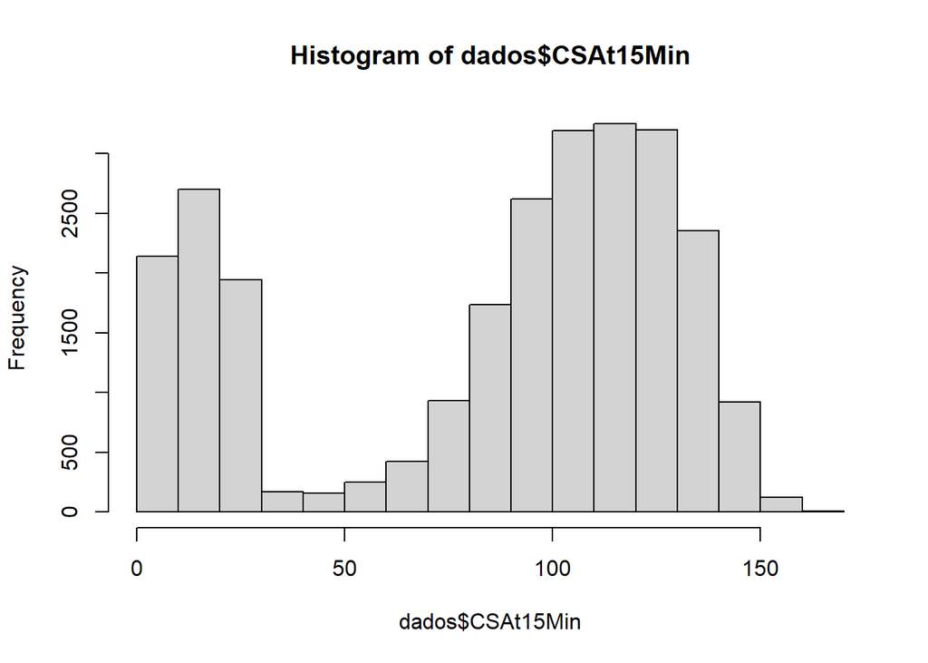

```r
hist(dados$CSAt15Min)
```

E esse é um sumário dos dados em forma de tabela.

```r
summary(dados$CSAt15Min)
```

```
##    Min. 1st Qu.  Median    Mean 3rd Qu.    Max.
##    0.00   27.00  100.00   84.39  121.00  162.00
```

## Coluna CSAtEnd

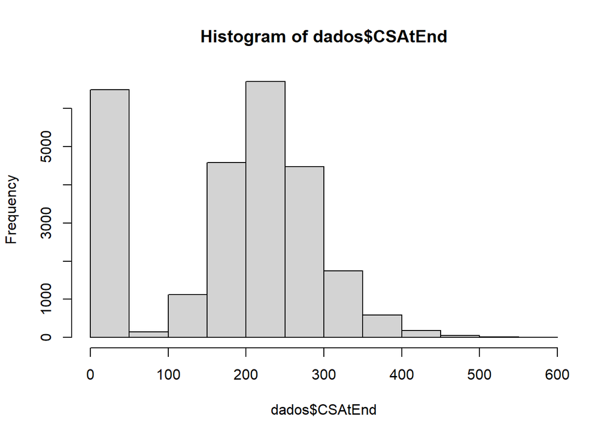

```r
hist(dados$CSAtEnd)
```

E esse é um sumário dos dados em forma de tabela.

```r
summary(dados$CSAtEnd)
```

```
##    Min. 1st Qu.  Median    Mean 3rd Qu.    Max.
##     0.0    52.0   206.0   181.8   255.0   574.0
```

## Colunas CSAt15Min vs. CSAtEnd

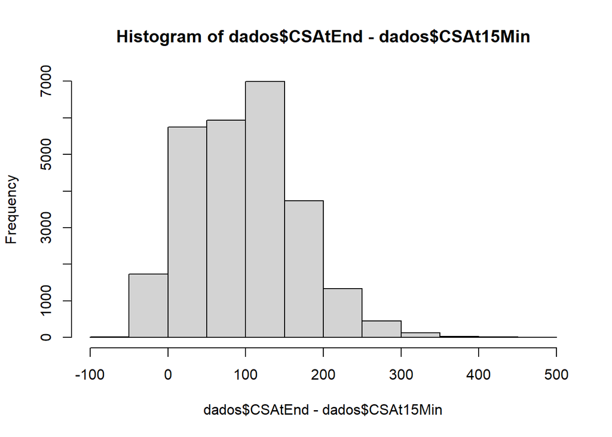

```r
hist(dados$CSAtEnd - dados$CSAt15Min)
```

E esse é um sumário dos dados em forma de tabela.

```r
summary(dados$CSAtEnd - dados$CSAt15Min)
```

```
##    Min. 1st Qu.  Median    Mean 3rd Qu.    Max.
##  -71.00   27.00   98.00   97.43  144.00  463.00
```

Finalmente, o número de casos em que a diferença de CS entre 15 minutos e fim do jogo é 0 ou negativa. Isso não deveria acontecer.

```r
sum((dados$CSAtEnd - dados$CSAt15Min) <= 0)
```

```
## [1] 1751
```

## Coluna GoldAt15Min

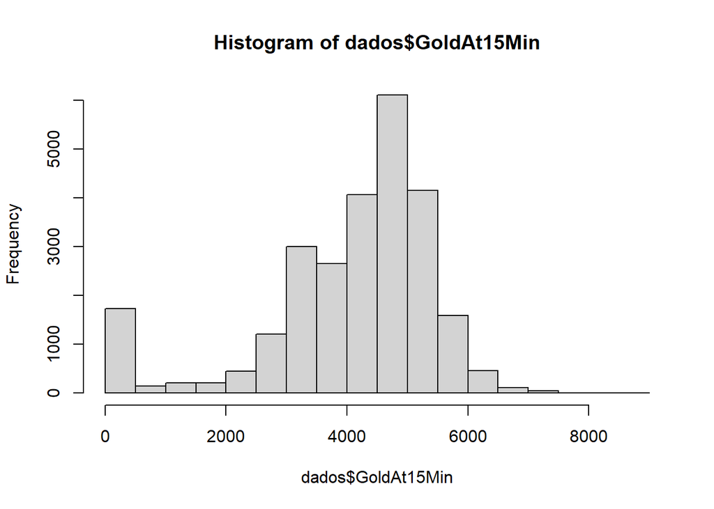

```r
hist(dados$GoldAt15Min)
```

E esse é um sumário dos dados em forma de tabela.

```r
summary(dados$GoldAt15Min)
```

```
##    Min. 1st Qu.  Median    Mean 3rd Qu.    Max.
##       0    3428    4445    4060    4985    8847
```

Agora, o mesmo histograma para um recorte mais específico.

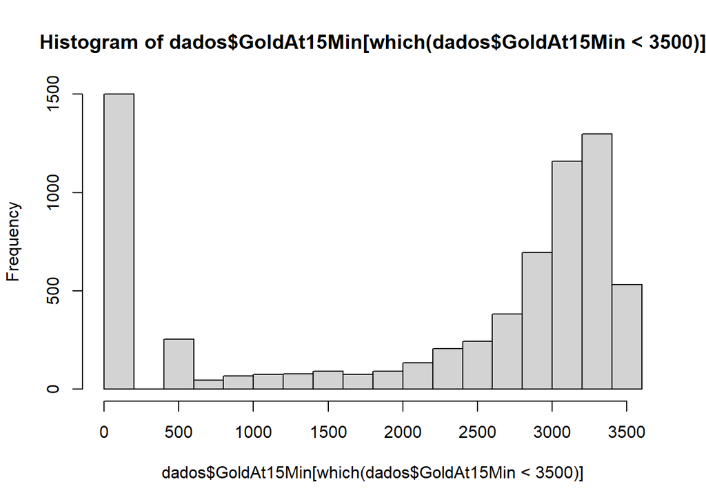

```r
hist(dados$GoldAt15Min[which(dados$GoldAt15Min < 3500)])
```

E esse é o número de casos em que o ouro em 15 minutos continua parado no 500.

```r
sum((dados$GoldAt15Min) == 500)
```

```
## [1] 229
```

## Coluna GoldAtEnd

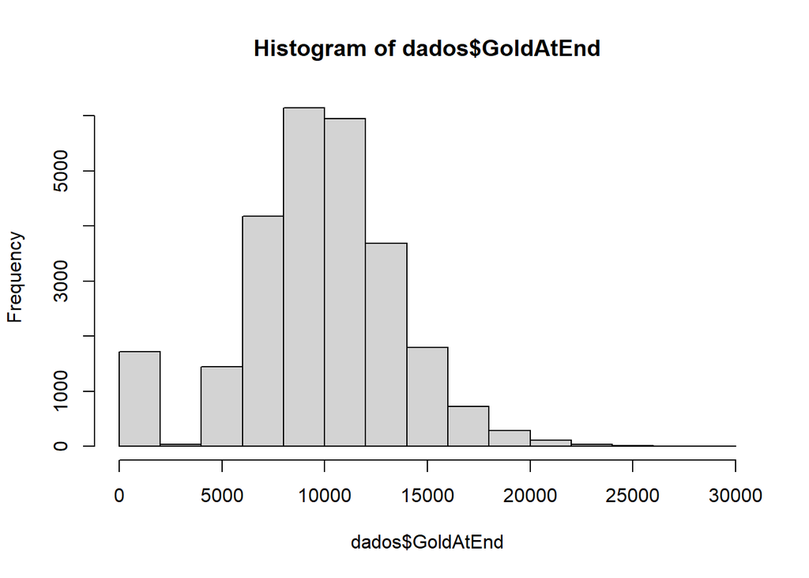

```r
hist(dados$GoldAtEnd)
```

E esse é um sumário dos dados em forma de tabela.

```r
summary(dados$GoldAtEnd)
```

```
##    Min. 1st Qu.  Median    Mean 3rd Qu.    Max.
##       0    7684    9864    9709   12062   28354
```

Agora, o mesmo histograma para um recorte mais específico.

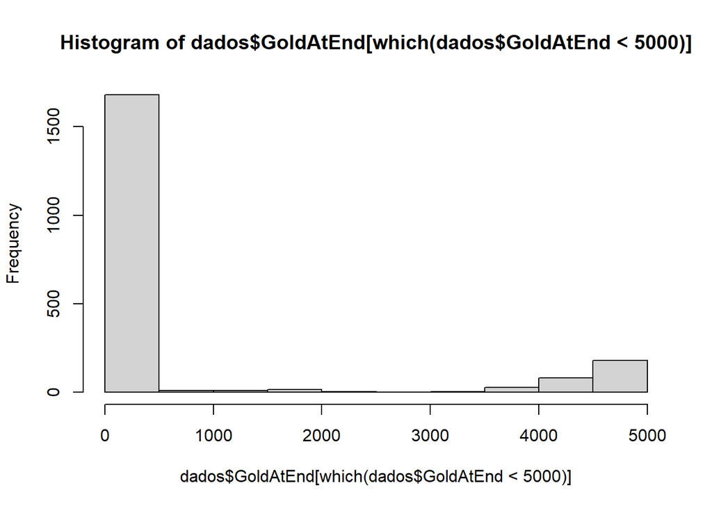

```r
hist(dados$GoldAtEnd[which(dados$GoldAtEnd < 5000)])
```

E esse é o número de casos em que o ouro ao final continua parado no 500.

```r
sum((dados$GoldAtEnd) == 500)
```

```
## [1] 209
```

## Colunas GoldAt15Min vs. GoldAtEnd

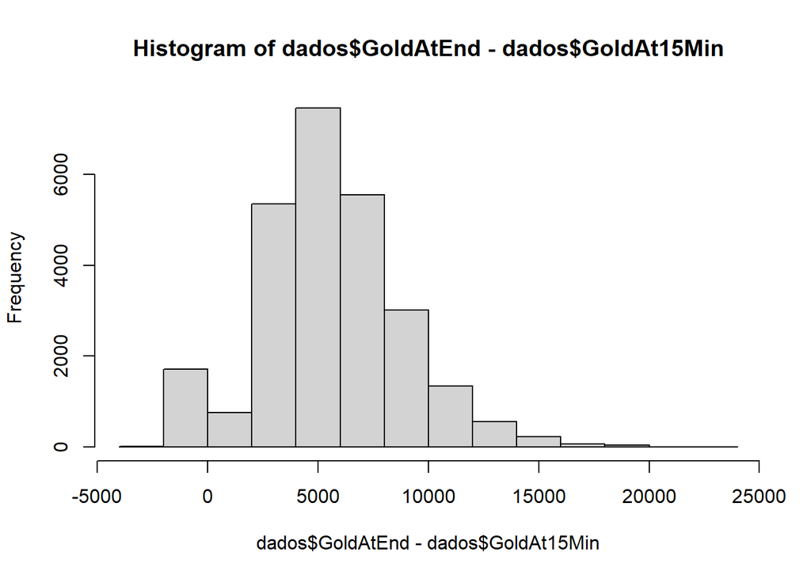

```r
hist(dados$GoldAtEnd - dados$GoldAt15Min)
```

E esse é um sumário dos dados em forma de tabela.

```r
summary(dados$GoldAtEnd - dados$GoldAt15Min)
```

```
##    Min. 1st Qu.  Median    Mean 3rd Qu.    Max.
##   -3072    3637    5374    5650    7453   23156
```

Agora, o mesmo histograma para um recorte mais específico.

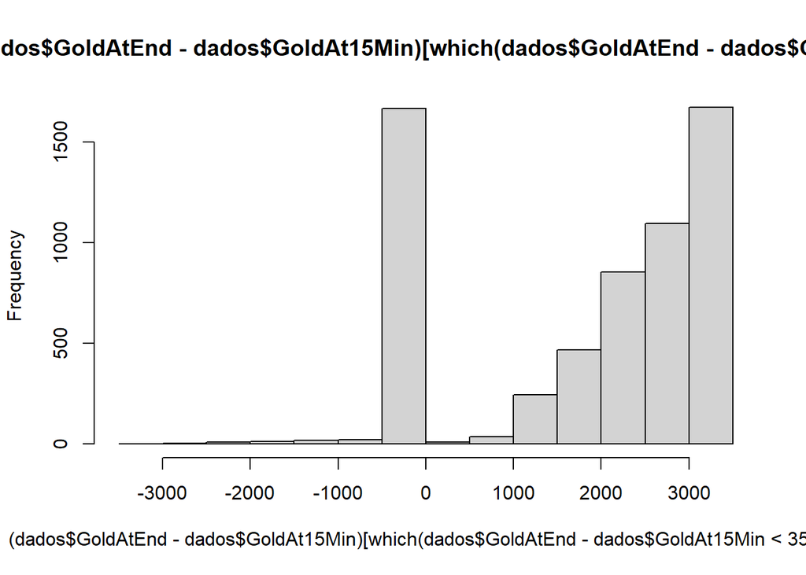

```r
hist(
  (dados$GoldAtEnd - dados$GoldAt15Min)[
    which(dados$GoldAtEnd - dados$GoldAt15Min < 3500)
  ]
)
```

E esse é o número de casos em que a diferença de ouro entre 15 minutos e fim do jogo é 0 ou negativa. Isso não deveria acontecer.

```r
sum((dados$GoldAtEnd - dados$GoldAt15Min) <= 0)
```

```
## [1] 1730
```

# Checagem das linhas com dados inesperados

Agora vamos começar a pensar em excluir as linhas problemáticas.

```r
linhas_em_que_ouro_comecou_como_zero <- which(dados$GoldAt15Min == 0)
linhas_em_que_ouro_terminou_como_zero <- which(dados$GoldAtEnd == 0)
linhas_em_que_ouro_comecou_ou_terminou_como_zero <- which(
  dados$GoldAt15Min == 0 |
    dados$GoldAtEnd == 0
)
linhas_em_que_a_diferenca_de_CS_ao_final_do_jogo_foi_0_ou_negativa <- which(
  dados$CSAtEnd - dados$CSAt15Min <= 0
)
linhas_em_que_a_diferenca_de_ouro_ao_final_do_jogo_foi_0_ou_negativa <- which(
  dados$GoldAtEnd - dados$GoldAt15Min <= 0
)
linhas_em_que_ocorreu_qualquer_um_dos_4_problemas <- which(
  dados$GoldAt15Min == 0 |
    dados$GoldAtEnd == 0 |
    dados$CSAtEnd - dados$CSAt15Min <= 0|
    dados$GoldAtEnd - dados$GoldAt15Min <= 0
)
length(linhas_em_que_ocorreu_qualquer_um_dos_4_problemas)
```

```
## [1] 1771
```

Vamos excluir essas 1771 linhas que achamos que são problemáticas. E agora vamos refazer algumas checagens.

## Coluna GameID

```r
sort(
  table(
    dados[-linhas_em_que_ocorreu_qualquer_um_dos_4_problemas,]$GameID
  ),
  decreasing = FALSE
)
```

```
##
## 114030078203128372 113668118971722289 113685278535245908 113871278446985915
##                  8                  9                  9                  9
## 113979392954355342 114030078203128380 114161485626420175 114183452239614358
##                  9                  9                  9                  9
## 114194683848551657 114234196579074184 113470687277255856 113470687277255859
##                  9                  9                 10                 10
## 113470687277255863 113470687277255864 113470687277255868 113470687277255871
##                 10                 10                 10                 10
## 113470687277255872 113470687277255873 113470687277255875 113470687277255876
##                 10                 10                 10                 10
## 113470687277255877 113470687277255879 113470687277255880 113470687277255881
##                 10                 10                 10                 10
## 113470687277255884 113470687277255885 113470687277255887 113470740396151228
##                 10                 10                 10                 10
```

[output cut: 1204 more lines]

Vemos que alguns jogos ficaram com menos de 10 observações. Talvez possamos manter apenas os dados desses jogos, se os valores esquisitos fizerem sentido

```r
linhas_com_jogos_que_ficaram_com_dados_faltando <- dados[
  which(
    dados$GameID %in% (
      names(which(
        table(
          dados[-linhas_em_que_ocorreu_qualquer_um_dos_4_problemas,]$GameID
        ) <10
      ))
    )
  ),
]
linhas_com_jogos_que_ficaram_com_dados_faltando
```

```
##                   GameID          RedTeamID         BlueTeamID
## 61    114161485626420175 113865629782947798 110424394375218208
## 62    114161485626420175 113865629782947798 110424394375218208
## 63    114161485626420175 113865629782947798 110424394375218208
## 64    114161485626420175 113865629782947798 110424394375218208
## 65    114161485626420175 113865629782947798 110424394375218208
## 66    114161485626420175 113865629782947798 110424394375218208
## 67    114161485626420175 113865629782947798 110424394375218208
## 68    114161485626420175 113865629782947798 110424394375218208
## 69    114161485626420175 113865629782947798 110424394375218208
## 70    114161485626420175 113865629782947798 110424394375218208
## 1351  113685278535245908 107700204561086446 109692074894483834
## 1352  113685278535245908 107700204561086446 109692074894483834
## 1353  113685278535245908 107700204561086446 109692074894483834
## 1354  113685278535245908 107700204561086446 109692074894483834
```

[output cut: 490 more lines]

Podemos ver analisando esses jogos que eles foram injustamente punidos.Então, não vamos excluir as linhas referentes a eles.

# Dados sem linhas problemáticas

```r
'%!in%' <- function(x,y)!('%in%'(x,y))
linhas_problematicas <- which(
  (
    dados$GoldAt15Min == 0 |
      dados$GoldAtEnd == 0 |
      dados$CSAtEnd - dados$CSAt15Min <= 0|
      dados$GoldAtEnd - dados$GoldAt15Min <= 0
  )
  & dados$GameID %!in% (
      names(which(
        table(
          dados[-linhas_em_que_ocorreu_qualquer_um_dos_4_problemas,]$GameID
        ) <10
      ))
    )
)
write.csv2(
  dados[-linhas_problematicas,],
  file = "Script 1 - Dados sem linhas com problemas claros.csv"
)
```